# Module 3: Microbial Growth Curves

MB 360: Scientific Inquiry in Microbiology At the Bench

Carlos C. Goller, Ph.D.

NC State University | Department of Biological Sciences

Camila Loyola, Graduate Teaching Assistant

2026-09-08

## Module 3: Microbial Growth Curves

MB 360: Scientific Inquiry in Microbiology At the Bench

MB 360 Lab Workbook  
NC State University | Department of Biological Sciences

## Overview

**Weeks 4–5** · Growth curves · Biofilm assays · 96-well plate workflows

- Compare growth and biofilm formation among *Delftia* strains and student isolates
- Practice plate-based culture setup, controls, and multichannel pipetting
- Investigate biofilm formation differences among isolates

## Learning Outcomes

- **List** safety considerations for propagating microbes
- **Explain** the differences between static and shaking growth
- **Describe** the features of biofilms
- **Discuss** the significance of growth curves
- **Practice** multichannel pipetting and diluting overnight cultures
- **Collect** and **interpret** growth and biofilm data
- **Create** an annotated bibliography with at least five sources

## Skills & Knowledge

Skills

- Work safely with liquid cultures in 96-well plates
- Document protocols and results clearly
- Interpret growth-curve and biofilm data
- Propagate bacteria in liquid culture

Knowledge

- PPE requirements for microbial work
- Propagation in liquid media
- Seeding 96-well plates for growth and biofilm analyses

## Lab Safety

- Wear required PPE
- Clean the bench and pipettors with 70% ethanol
- Treat all tips as biohazards
- Dispose of plates and gloves in the correct waste streams

## Methods: Liquid Culture Setup

1. Isolated colonies were transferred to liquid medium
2. Inoculated tubes were grown **overnight at 30 °C** with shaking at 200–250 RPM

## Methods: Growth Assay Setup

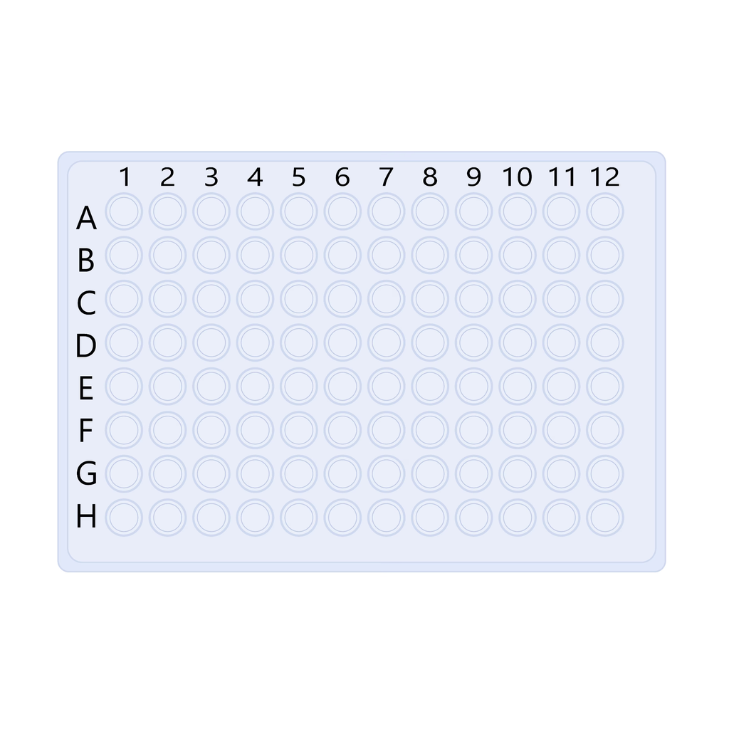

Blank 96-well plate layout for planning growth-curve wells and controls.

- Prepare 1:1000 dilutions of overnight cultures
- Use positive and negative controls
- Add 100 µL per well with multichannel pipette
- Seal with breathable seal; load into plate reader at 30 °C for 48 h

## Methods: Biofilm Viability Assay

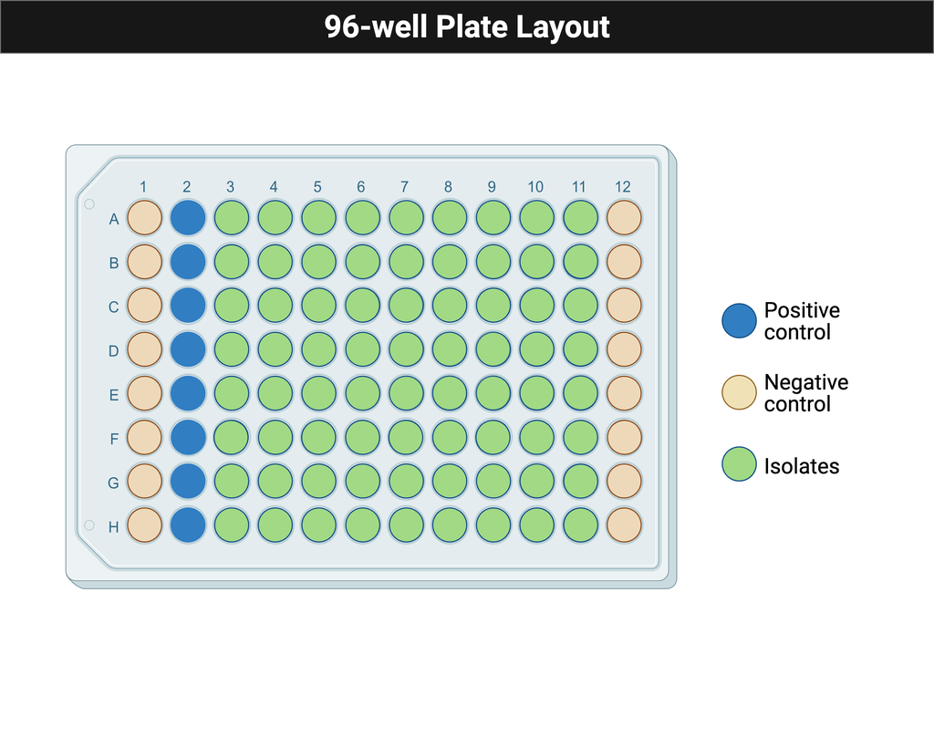

Crystal violet staining layout for quantifying biofilm biomass in a 96-well plate.

1. Remove medium from static-growth wells at 24 h and 48 h time points
2. Wash each well gently with **sterile PBS** (×2) to remove planktonic cells
3. Add **125 µL 0.1% crystal violet**; incubate 15 min at room temperature
4. Remove stain; wash wells ×3 with PBS until wash runs clear
5. Solubilise retained stain with **125 µL 30% acetic acid**
6. Transfer to a clean plate; read absorbance at **590 nm**

## Results & Discussion

- Plot **OD600** growth curves for each isolate and species compared
- Plot **OD590** biofilm values at 24 h and 48 h
- Identify which isolate forms the most and least biofilm
- Discuss what the results suggest about isolate lifestyle (planktonic vs. sessile)

## Reflection Questions

1. Why are positive and negative controls essential for growth-curve experiments?
2. What could cause a flat growth curve even when viable cells were added?
3. How does biofilm formation relate to antibiotic resistance or environmental persistence?